# The Bootstrap

Peter Ralph

Advanced Biological Statistics

# Estimating sampling error

## Standard error

From a single set of numbers

$$x_1, x_2, \ldots, x_n$$

we can get both a *mean*:

$$\bar x = \frac{1}{n} \sum_{i=1}^n x_i$$

**and** an estimate of the *variability* of the mean, the *standard error*:

$$\frac{s}{\sqrt{n}} = \sqrt{\frac{1}{n(n-1)}\sum_{i=1}^n \left(x_i - \bar x\right)^2 } .$$

This is amazing!

Sadly, it’s not so easy to simply compute a standard error for most estimates.

What to do?

# Enter the bootstrap

**Idea:**

- We’d *like* to get a whole new dataset, and repeat the estimation, to see how different the answer is.
- And, well, our best guess at what the data look like is **our dataset itself**,
- *sooooo,* let’s just *resample from the dataset*, with replacement, to make a “new” dataset!
- If we resample and re-estimate lots of times, this should give us a good idea of the variability of the estimate.

## The bootstrap resampling algorithm

To estimate the uncertainty of an estimate:

1. Use the computer to take a random sample of observations from the original data, with replacement.
2. Calculate the estimate from the resampled data set.
3. Repeat 1-2 many times.
4. The standard deviation of these esimates is the **bootstrap standard error**.

## Advantages

- Applies to most any statistic
- Works when there’s no simple formula for the standard error (e.g., median, trimmed mean, eigenvalue, etc)
- Is *nonparametric*, so doesn’t make specific assumptions about the distribution of the data.
- Applies to even complicated sampling procedures.

## Exercise

```r
x <- c(0.6, 1, 3.1, 3.7, 4.8, 6.2, 12.5, 12.5, 13.4, 24.1)
```

- Use R to make 1000 “pseudo-samples” of size 10 (with replacement),
- and store the mean of each in a vector.
- Plot the histogram of the resampled means, and calculate their standard deviation (with `sd()`).
- How does this compare to the usual standard error of the mean, `sd(x) / sqrt(length(x))`?

## in class

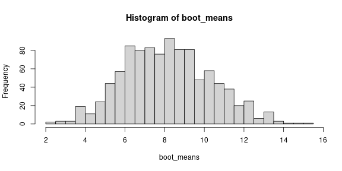

```r
x <- c(0.6, 1, 3.1, 3.7, 4.8, 6.2, 12.5, 12.5, 13.4, 24.1)
num_boots <- 1000
xboot <- matrix(NA, nrow=length(x), ncol=num_boots)
for (j in 1:num_boots) {
    xboot[,j] <- sample(x, size=length(x), replace=TRUE)
}
boot_means <- colMeans(xboot)
hist(boot_means, breaks=40)
```

```r
sprintf("The standard deviation is %f, while the standard error is %f.",
        sd(boot_means),
        sd(x)/sqrt(length(x)))
```

```
## [1] "The standard deviation is 2.199000, while the standard error is 2.329161."
```

## Confidence intervals?

The 2.5% and 97.5% percentiles of the bootstrap samples estimate a 95% confidence interval. (use the `quantile( )` function)

*Exercise:* get a 95% CI and compare it to that given by `t.test( )`.